# Capstone

### Introduction

Information gathered uses Pandas, and Pandas Data-reader which are Python libraries used to request data from Yahoo Finance's API for me to wrangle and develop models with. All of my code is sitting in a Jupyter Notebook environment so data does not need to be stored or maintained in a database. If in the future a database were to be used for deployment purposes I would most likely move data to a Heroku Dyno and set up a Postgres environment to act as the managed database. In doing so I could potentially create an interactive tool for investors to use online.

### 1. Import Packages Data Manipulation Packages

Importing all of the required dependencies.

```python
import datetime as dt
import emoji
import matplotlib.pyplot as plt
from matplotlib import style
import numpy as np
import pandas as pd
import pandas_datareader.data as web
import plotly.graph_objs as go
import plotly.offline as offline_py
from rf import return_portfolios, optimal_portfolio
offline_py.init_notebook_mode(connected=True)
%matplotlib inline
```

### 2. Load the adjusted closings for the 15 tech stocks.

Using Pandas data-reader to pull stock data from Yahoo Finance API, create dates, retrieve data, and view data.

```python
symbols = ["MSFT", "AMZN", "AAPL", "GOOG", "FB",
           "CRM", "CSCO", "NVDA", "AMD", "NFLX",
           "DOCU", "SQ", "ORCL", "TSLA", "TWTR"]
delta = dt.timedelta(days=365)
end_date = dt.datetime.now()
start_date = dt.datetime.now() - delta
stock_data = web.get_data_yahoo(symbols, start_date, end_date)
```

Focusing on Adjusted Close for analysis

```python
close = stock_data['Adj Close']
close.head()
```

| Symbols Date | AAPL | AMD | AMZN | CRM | CSCO | DOCU | FB | GOOG | MSFT | NFLX | NVDA | ORCL | SQ | TSLA | TWTR |
| --- | --- | --- | --- | --- | --- | --- | --- | --- | --- | --- | --- | --- | --- | --- | --- |
| 2018-12-10 | 167.089478 | 19.990000 | 1641.030029 | 137.270004 | 45.572453 | 40.689999 | 141.850006 | 1039.550049 | 106.022339 | 269.700012 | 151.269226 | 45.887451 | 63.380001 | 365.149994 | 33.430000 |
| 2018-12-11 | 166.133850 | 19.980000 | 1643.239990 | 136.789993 | 45.796131 | 41.660000 | 142.080002 | 1051.750000 | 107.007774 | 265.320007 | 147.613510 | 45.680977 | 61.779999 | 366.760010 | 34.450001 |
| 2018-12-12 | 166.596878 | 20.480000 | 1663.540039 | 140.089996 | 46.117062 | 42.400002 | 144.500000 | 1063.680054 | 107.490639 | 274.880005 | 148.320740 | 46.526558 | 63.650002 | 366.600006 | 36.250000 |
| 2018-12-13 | 168.419479 | 19.860001 | 1658.380005 | 141.139999 | 46.165691 | 43.150002 | 145.009995 | 1061.900024 | 107.855240 | 276.019989 | 148.310776 | 46.438068 | 62.900002 | 376.790009 | 35.889999 |
| 2018-12-14 | 163.030457 | 19.900000 | 1591.910034 | 137.039993 | 44.561028 | 42.889999 | 144.059998 | 1042.099976 | 104.485077 | 266.839996 | 145.880264 | 45.818630 | 62.139999 | 365.709991 | 35.869999 |

Here's our Tech Stock Universe:

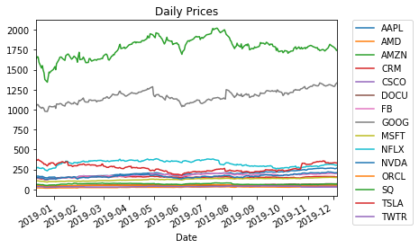

```python
close.plot()
plt.legend(bbox_to_anchor=(1.05, 1), loc='upper left', borderaxespad=0.)
plt.title('Daily Prices');
```

### Stock Example

In order to demonstrate the use of log returns and resampling, I've used Google's stock (GOOG). However, these transformations are applied to all assets in my stock universe.

```python
color_scheme = {
    'index': '#B6B2CF',
    'etf': '#2D3ECF',
    'tracking_error': '#6F91DE',
    'df_header': 'silver',
    'df_value': 'white',
    'df_line': 'silver',
    'heatmap_colorscale': [(0, '#6F91DE'), (0.5, 'grey'), (1, 'red')],
    'background_label': '#9dbdd5',
    'low_value': '#B6B2CF',
    'high_value': '#2D3ECF',
    'y_axis_2_text_color': 'grey',
    'shadow': 'rgba(0, 0, 0, 0.75)',
    'major_line': '#2D3ECF',
    'minor_line': '#B6B2CF',
    'main_line': 'black'}
```

```python
def _generate_stock_trace(prices):
    return go.Scatter(
        name='Index',
        x=prices.index,
        y=prices,
        line={'color': color_scheme['major_line']})

def plot_stock(prices, title):
    config = generate_config()
    layout = go.Layout(title=title)

    stock_trace = _generate_stock_trace(prices)

    offline_py.iplot({'data': [stock_trace], 'layout': layout})
```

```python
goog_ticker = 'GOOG'
plot_stock(close[goog_ticker], f'{goog_ticker} Stock')
```

[interactive chart not shown]

### Resample Adjusted Prices

Resampling the daily adjusted closing prices into monthly buckets, and selecting the last observation of each month.

```python
def resample_prices(close_prices, freq='M'):
    """
    Resample close prices for each ticker and return month end prices.
    """
    return close_prices.resample(freq).last()
```

```python
def _generate_traces(name_df_color_data):
    traces = []

    for name, df, color in name_df_color_data:
        traces.append(go.Scatter(
            name=name,
            x=df.index,
            y=df,
            mode='line',
            line={'color': color}))

    return traces

def plot_resampled_prices(df_resampled, df, title):
    config = generate_config()
    layout = go.Layout(title=title)

    traces = _generate_traces([
        ('Monthly Close', df_resampled, color_scheme['major_line']),
        ('Close', df, color_scheme['minor_line'])])

    offline_py.iplot({'data': traces, 'layout': layout})
```

```python
monthly_close = resample_prices(close)
plot_resampled_prices(
    monthly_close.loc[:, goog_ticker],
    close.loc[:, goog_ticker],
    f'{goog_ticker} Stock - Close Vs Monthly Close')
```

[interactive chart not shown]

```python
def compute_log_returns(prices):
    """
    Compute log returns for each ticker.
    """
    return np.log(prices) - np.log(prices.shift(1))
```

```python
def plot_returns(returns, title):
    layout = go.Layout(title=title)

    traces = _generate_traces([
        ('Returns', returns, color_scheme['major_line'])])

    offline_py.iplot({'data': traces, 'layout': layout})
```

```python
monthly_close_returns = compute_log_returns(monthly_close)
plot_returns(
    monthly_close_returns.loc[:, goog_ticker],
    f'Log Returns of {goog_ticker} Stock (Monthly)')
```

[interactive chart not shown]

### Here are the monthly log returns of our entire data set:

Log returns are used in order to create probability distributions based on a normal dataset.

```python
monthly_close_returns
```

| Symbols Date | AAPL | AMD | AMZN | CRM | CSCO | DOCU | FB | GOOG | MSFT | NFLX | NVDA | ORCL | SQ | TSLA | TWTR |
| --- | --- | --- | --- | --- | --- | --- | --- | --- | --- | --- | --- | --- | --- | --- | --- |
| 2018-12-31 | NaN | NaN | NaN | NaN | NaN | NaN | NaN | NaN | NaN | NaN | NaN | NaN | NaN | NaN | NaN |
| 2019-01-31 | 0.053687 | 0.279387 | 0.134808 | 0.103921 | 0.095167 | 0.210085 | 0.240252 | 0.075092 | 0.027769 | 0.237756 | 0.073974 | 0.110573 | 0.240640 | -0.080629 | 0.155045 |
| 2019-02-28 | 0.043803 | -0.036717 | -0.046993 | 0.074047 | 0.090512 | 0.109095 | -0.031940 | 0.003175 | 0.074511 | 0.053338 | 0.071594 | 0.037128 | 0.129810 | 0.041033 | -0.086470 |
| 2019-03-31 | 0.092603 | 0.081186 | 0.082442 | -0.032796 | 0.041988 | -0.061895 | 0.031940 | 0.046572 | 0.051409 | -0.004310 | 0.151870 | 0.029859 | -0.080987 | -0.133657 | 0.065999 |
| 2019-04-30 | 0.054901 | 0.079440 | 0.078681 | 0.043130 | 0.041971 | 0.089083 | 0.148625 | 0.012846 | 0.101963 | 0.038459 | 0.007988 | 0.034185 | -0.028430 | -0.159124 | 0.193762 |
| 2019-05-31 | -0.132632 | -0.007994 | -0.081875 | -0.088073 | -0.072638 | -0.010822 | -0.085959 | -0.074070 | -0.050747 | -0.076415 | -0.288680 | -0.089364 | -0.161663 | -0.253945 | -0.090960 |
| 2019-06-30 | 0.122677 | 0.102547 | 0.064656 | 0.002111 | 0.050592 | -0.120216 | 0.083889 | -0.020801 | 0.079844 | 0.067687 | 0.192591 | 0.118573 | 0.157673 | 0.188012 | -0.043180 |
| 2019-07-31 | 0.073617 | 0.002631 | -0.014281 | 0.018091 | 0.018459 | 0.039638 | 0.006353 | 0.118323 | 0.017097 | -0.128612 | 0.026973 | -0.007791 | 0.103138 | 0.078092 | 0.192537 |
| 2019-08-31 | -0.016598 | 0.032313 | -0.049688 | 0.010111 | -0.168483 | -0.102315 | -0.045072 | -0.023771 | 0.014925 | -0.094892 | -0.006208 | -0.078298 | -0.262588 | -0.068517 | 0.008004 |
| 2019-09-30 | 0.070423 | -0.081448 | -0.022995 | -0.050124 | 0.054056 | 0.282313 | -0.041738 | 0.025675 | 0.008451 | -0.093161 | 0.038415 | 0.055482 | 0.001777 | 0.065450 | -0.034589 |
| 2019-10-31 | 0.104976 | 0.157349 | 0.023203 | 0.052811 | -0.031667 | 0.066686 | 0.073438 | 0.033168 | 0.030739 | 0.071342 | 0.143947 | -0.005411 | -0.008429 | 0.268061 | -0.318241 |
| 2019-11-30 | 0.074694 | 0.143101 | 0.013496 | 0.040083 | -0.047412 | 0.073104 | 0.050813 | 0.034973 | 0.057762 | 0.090583 | 0.076032 | 0.029831 | 0.117946 | 0.046592 | 0.030883 |
| 2019-12-31 | 0.012864 | 0.012186 | -0.027701 | -0.030417 | -0.032981 | 0.059426 | -0.002930 | 0.026960 | 0.002441 | -0.023506 | -0.021311 | -0.023611 | -0.016631 | 0.017873 | -0.023569 |

```python
def shift_returns(returns, shift_n):
    """
    Generate shifted returns
    """
    return returns.shift(shift_n)
```

```python
prev_returns = shift_returns(monthly_close_returns, 1)
```

```python
prev_returns
```

| Symbols Date | AAPL | AMD | AMZN | CRM | CSCO | DOCU | FB | GOOG | MSFT | NFLX | NVDA | ORCL | SQ | TSLA | TWTR |
| --- | --- | --- | --- | --- | --- | --- | --- | --- | --- | --- | --- | --- | --- | --- | --- |
| 2018-12-31 | NaN | NaN | NaN | NaN | NaN | NaN | NaN | NaN | NaN | NaN | NaN | NaN | NaN | NaN | NaN |
| 2019-01-31 | NaN | NaN | NaN | NaN | NaN | NaN | NaN | NaN | NaN | NaN | NaN | NaN | NaN | NaN | NaN |
| 2019-02-28 | 0.053687 | 0.279387 | 0.134808 | 0.103921 | 0.095167 | 0.210085 | 0.240252 | 0.075092 | 0.027769 | 0.237756 | 0.073974 | 0.110573 | 0.240640 | -0.080629 | 0.155045 |
| 2019-03-31 | 0.043803 | -0.036717 | -0.046993 | 0.074047 | 0.090512 | 0.109095 | -0.031940 | 0.003175 | 0.074511 | 0.053338 | 0.071594 | 0.037128 | 0.129810 | 0.041033 | -0.086470 |
| 2019-04-30 | 0.092603 | 0.081186 | 0.082442 | -0.032796 | 0.041988 | -0.061895 | 0.031940 | 0.046572 | 0.051409 | -0.004310 | 0.151870 | 0.029859 | -0.080987 | -0.133657 | 0.065999 |
| 2019-05-31 | 0.054901 | 0.079440 | 0.078681 | 0.043130 | 0.041971 | 0.089083 | 0.148625 | 0.012846 | 0.101963 | 0.038459 | 0.007988 | 0.034185 | -0.028430 | -0.159124 | 0.193762 |
| 2019-06-30 | -0.132632 | -0.007994 | -0.081875 | -0.088073 | -0.072638 | -0.010822 | -0.085959 | -0.074070 | -0.050747 | -0.076415 | -0.288680 | -0.089364 | -0.161663 | -0.253945 | -0.090960 |
| 2019-07-31 | 0.122677 | 0.102547 | 0.064656 | 0.002111 | 0.050592 | -0.120216 | 0.083889 | -0.020801 | 0.079844 | 0.067687 | 0.192591 | 0.118573 | 0.157673 | 0.188012 | -0.043180 |
| 2019-08-31 | 0.073617 | 0.002631 | -0.014281 | 0.018091 | 0.018459 | 0.039638 | 0.006353 | 0.118323 | 0.017097 | -0.128612 | 0.026973 | -0.007791 | 0.103138 | 0.078092 | 0.192537 |
| 2019-09-30 | -0.016598 | 0.032313 | -0.049688 | 0.010111 | -0.168483 | -0.102315 | -0.045072 | -0.023771 | 0.014925 | -0.094892 | -0.006208 | -0.078298 | -0.262588 | -0.068517 | 0.008004 |
| 2019-10-31 | 0.070423 | -0.081448 | -0.022995 | -0.050124 | 0.054056 | 0.282313 | -0.041738 | 0.025675 | 0.008451 | -0.093161 | 0.038415 | 0.055482 | 0.001777 | 0.065450 | -0.034589 |
| 2019-11-30 | 0.104976 | 0.157349 | 0.023203 | 0.052811 | -0.031667 | 0.066686 | 0.073438 | 0.033168 | 0.030739 | 0.071342 | 0.143947 | -0.005411 | -0.008429 | 0.268061 | -0.318241 |
| 2019-12-31 | 0.074694 | 0.143101 | 0.013496 | 0.040083 | -0.047412 | 0.073104 | 0.050813 | 0.034973 | 0.057762 | 0.090583 | 0.076032 | 0.029831 | 0.117946 | 0.046592 | 0.030883 |

### Determine what stocks to take a long or short position in:

Below is a function that I have written to generate a list of the stocks that have increased the most of the past year -e.g. taken the most long position over the given timeframe.

```python
def get_top_n(prev_returns, top_n):
    """
    Select the top performing stocks
    """
    res = pd.DataFrame(columns=prev_returns.columns)

    for index, row in prev_returns.iterrows():
        curr_month = row
        curr_top = pd.Series(curr_month).nlargest(top_n)
        top = list(curr_top.index.values)
        for col in res.columns:
            if(col in top):
                res.loc[index, col] = True
            else:
                res.loc[index, col] = False

    for index, row in res.iterrows():
        res.loc[index] = res.loc[index].astype('int64')
    #print(res.head())
    return res
```

```python
def print_top(df, name, top_n=5):
    print('{} Most {}:'.format(top_n, name))
    print(', '.join(df.sum().sort_values(ascending=False).index[:top_n].values.tolist()))
```

### Calculate and Display the Most Long Stocks and Most Short Stocks

By simply applying the multiplication of -1, I use the same function to generate the most short stocks over the provided timeframe.

```python
top_bottom_n = 10
df_long = get_top_n(prev_returns, top_bottom_n)
df_short = get_top_n(-1*prev_returns, top_bottom_n)
print_top(df_long, 'Longed Stocks')
print_top(df_short, 'Shorted Stocks')
```

```
5 Most Longed Stocks:
MSFT, AAPL, NVDA, FB, DOCU
5 Most Shorted Stocks:
AMZN, ORCL, NFLX, GOOG, CRM
```

### What if we create a portfolio of the 5 most longed stocks?

```python
long_stocks = ["MSFT", "AAPL", "NVDA", "FB", "DOCU"]
```

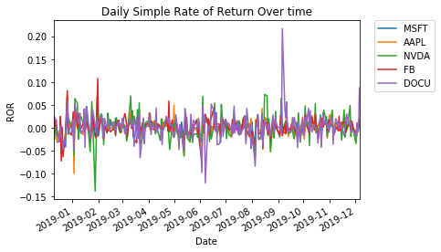

```python
stock_data_daily_returns = stock_data['Adj Close'][long_stocks].pct_change()
stock_data_daily_returns.plot()
plt.xlabel("Date")
plt.ylabel("ROR")
plt.title("Daily Simple Rate of Return Over time")
plt.legend(bbox_to_anchor=(1.05, 1), loc='upper left', borderaxespad=0.);
```

### Daily simple rates of return:

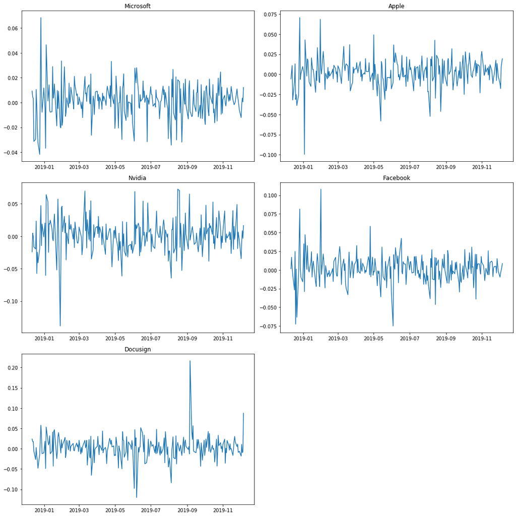

```python
["MSFT", "AAPL", "NVDA", "FB", "DOCU"]
fig = plt.figure(figsize=(15,15))
ax1 = fig.add_subplot(321)
ax2 = fig.add_subplot(322)
ax3 = fig.add_subplot(323)
ax4 = fig.add_subplot(324)
ax5 = fig.add_subplot(325)
ax1.plot(stock_data['Adj Close']['MSFT'].pct_change())
ax1.set_title("Microsoft")
ax2.plot(stock_data['Adj Close']['AAPL'].pct_change())
ax2.set_title("Apple")
ax3.plot(stock_data['Adj Close']['NVDA'].pct_change())
ax3.set_title("Nvidia")
ax4.plot(stock_data['Adj Close']['FB'].pct_change())
ax4.set_title("Facebook")
ax5.plot(stock_data['Adj Close']['DOCU'].pct_change())
ax5.set_title("Docusign")
plt.tight_layout()
plt.show()
```

### Daily mean ROR:

```python
# calculate daily mean
daily_mean = stock_data_daily_returns.mean()

daily_mean
```

```
Symbols
MSFT    0.001533
AAPL    0.002088
NVDA    0.001702
FB      0.001581
DOCU    0.002878
dtype: float64
```

```python
# daily mean index for the x axis
daily_mean.keys()

# grab each daily mean value for the y axis
height = []
for key in daily_mean.keys():
    height.append(daily_mean[key])

# arrange keys on x axis based on length
x_pos = np.arange(len(daily_mean.keys()))
```

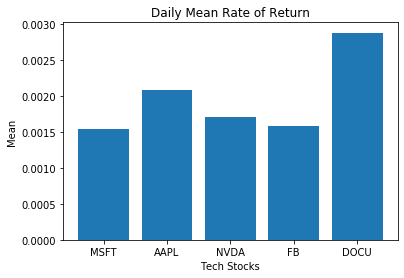

```python
# plot bars
plt.bar(x_pos, height)

# create names on the x-axis
plt.xticks(x_pos, daily_mean.keys())

# label chart
plt.xlabel("Tech Stocks")
plt.ylabel("Mean")
plt.title("Daily Mean Rate of Return")
plt.show()
```

### Daily Variance:

```python
# calculate variance
daily_var = stock_data_daily_returns.var()
daily_var
```

```
Symbols
MSFT    0.000197
AAPL    0.000311
NVDA    0.000693
FB      0.000374
DOCU    0.000816
dtype: float64
```

```python
# variance index for the x axis
daily_var.keys()

# grab each variance value for the y axis
height = []
for key in daily_var.keys():
    height.append(daily_var[key])
```

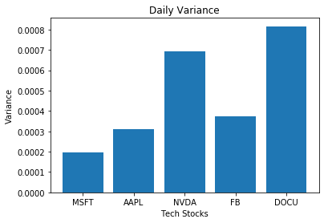

```python
# plot bars
plt.bar(x_pos, height)

# create names on the x-axis
plt.xticks(x_pos, daily_var.keys())

# label chart
plt.xlabel("Tech Stocks")
plt.ylabel("Variance")
plt.title("Daily Variance")

# show graphic
plt.show()
```

### Standard Deviation:

```python
# calculate standard deviation
daily_std = stock_data_daily_returns.std()
daily_std
```

```
Symbols
MSFT    0.014039
AAPL    0.017645
NVDA    0.026331
FB      0.019336
DOCU    0.028569
dtype: float64
```

```python
# grab each standard deviation value for the y axis
height = []
for key in daily_std.keys():
    height.append(daily_std[key])
```

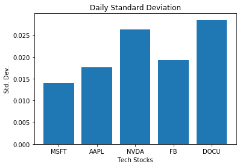

```python
# plot bars
plt.bar(x_pos, height)

# create names on the x-axis
plt.xticks(x_pos, daily_std.keys())

# label chart
plt.xlabel("Tech Stocks")
plt.ylabel("Std. Dev.")
plt.title("Daily Standard Deviation")

# show graphic
plt.show()
```

### Correlation in our portfolio:

```python
corr = stock_data_daily_returns.corr()
corr
```

| Symbols | MSFT | AAPL | NVDA | FB | DOCU |
| --- | --- | --- | --- | --- | --- |
| MSFT | 1.000000 | 0.671109 | 0.564095 | 0.567456 | 0.436929 |
| AAPL | 0.671109 | 1.000000 | 0.617088 | 0.538725 | 0.379871 |
| NVDA | 0.564095 | 0.617088 | 1.000000 | 0.487307 | 0.353498 |
| FB | 0.567456 | 0.538725 | 0.487307 | 1.000000 | 0.370899 |
| DOCU | 0.436929 | 0.379871 | 0.353498 | 0.370899 | 1.000000 |

[figure not shown]

```python
plt.imshow(cov)
plt.colorbar()
plt.xticks(rotation='horizontal')
plt.xticks(range(len(cov)), corr.columns)
plt.yticks(range(len(cov)), corr.columns);
```

### Covariance:

```python
cov = stock_data_daily_returns.cov()
cov
```

| Symbols | MSFT | AAPL | NVDA | FB | DOCU |
| --- | --- | --- | --- | --- | --- |
| MSFT | 0.000197 | 0.000166 | 0.000209 | 0.000154 | 0.000175 |
| AAPL | 0.000166 | 0.000311 | 0.000287 | 0.000184 | 0.000191 |
| NVDA | 0.000209 | 0.000287 | 0.000693 | 0.000248 | 0.000266 |
| FB | 0.000154 | 0.000184 | 0.000248 | 0.000374 | 0.000205 |
| DOCU | 0.000175 | 0.000191 | 0.000266 | 0.000205 | 0.000816 |

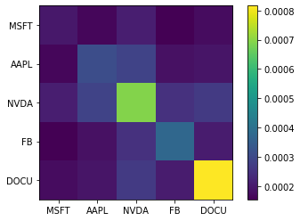

```python
plt.imshow(cov)
plt.colorbar()
plt.xticks(rotation='horizontal')
plt.xticks(range(len(cov)), cov.columns)
plt.yticks(range(len(cov)), cov.columns);
```

### Measuring the efficiency of this portfolio:

```python
# use the covariance
cov_monthly = monthly_close_returns[long_stocks][1:].cov()

# find the expected return
expected_returns = cov_monthly.mean()

# create a set of random portfolios
random_portfolios = return_portfolios(expected_returns, cov_monthly)
```

### Using Python's Cvxopt library to generate 5000 random portfolios:

[output not shown]

[output cut: 878 more lines]

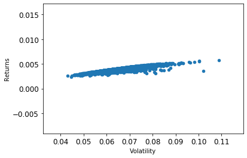

```python
# plot the set of random portfolios
random_portfolios.plot.scatter(x='Volatility', y='Returns', fontsize=12)

# calculate the set of portfolios on the EF
weights, returns, risks = optimal_portfolio(cov_monthly[1:])
```

Above I have generated a pool of 5000 random portfolios comprised of different combinations of the five longest stocks.

The following line (if uncommented) will generate a CSV filed called "all_five" that contains all risk and return values for all data points associated with our "longest portfolio".

```python
# pd.DataFrame({'Risks': risks, 'Returns': returns}).to_csv('all_five.csv', index=False)
```

```python
all_five_EF = pd.read_csv('all_five.csv')
```

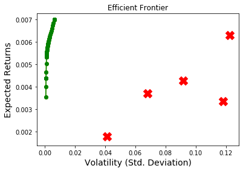

```python
# plot the set of portfolios on the EF
plt.plot(risks, returns, 'y-o')
plt.ylabel('Expected Returns',fontsize=14)
plt.xlabel('Volatility (Std. Deviation)',fontsize=14)
plt.title('Efficient Frontier')
single_asset_std=np.sqrt(np.diagonal(cov_monthly))
plt.scatter(single_asset_std,expected_returns,marker='X',color='red',s=200)
plt.plot(all_five_EF['Risks'], all_five_EF['Returns'], 'g-o')
plt.show();
```

### Conclusion

I have analyzed 15 of the most valuable tech stocks and generated a method for determining the optimal mix of goods in our portfolio.

Although I have taken a long-investor approach, the final functions provided can be used to cycle through various mixes of any stocks an individual chooses.